# Inequalities and Incarceration

Julia Russell

2022-11-22

## Abstract

This report investigates the inequalities that surround incarceration in the United States. I am doing so by using data from the Vera institute. This report will touch on the disproportionality of people of color being incarcerated and how jail populations have changed over 1970-2018 in both the states and the US overall.

## Introduction

In this report, I am investigating inequalities that surround incarceration in the United States. I am using data that comes from the Vera Institute. The Vera Institute is an organization that is working to fight injustices in the criminal justice system. The data I am using only gives us a small piece of the puzzle in regards to the issues that surround incarceration. Incarceration not only affects people who are incarcerated but also the people that surround them for the rest of their lives. People who are incarcerated have a stain against their name that affects their ability to rehabilitate themselves into society. That doesn’t even take into account an extra existing bias against people of color, especially if they were previously incarcerated. This dataset can aid in identifying any inequality patterns that occur with those who are incarcerated and where. By revealing these patterns, we know where we need to investigate further in what is causing these disparities. Some questions that are answered in this report are: Are POC (people of color) disproportionately incarcerated compared to white people?, How has jail populations in the US changed over time?, How has jail populations in a certain state changed when compared to other states?, Which type of county jails more people?, Where in the US are Black people being incarcerated disproportionately?.

## Data Summary

I chose to investigate the differences between the percent of the white population incarcerated and the percent of the POC population incarcerated across all types of counties across the US. This is important because looking at these differences helps to highlight racial inequality across types of counties

In rural counties, 32.57 percent of the population is white and 48.63 percent of them have been incarcerated. 7.1 percent of the population is POC and 33.37 percent of them have been incarcerated. From this information, we can conclude that POC has been incarcerated more than white people based on the concentration of both populations in rural counties.

In small/mid size counties, 31.84 percent of the population is white and 40.63 percent of them have been incarcerated. 11.37 percent of the population is POC and 47.11 percent of them have been incarcerated. From this information, we can conclude that POC has been incarcerated more than white people based on the concentration of both populations in small/mid size counties.

In suburban counties, 33.05 percent of the population is white and 41.75 percent of them have been incarcerated. 12.08 percent of the population is POC and 48.67 percent of them have been incarcerated. From this information, we can conclude that POC has been incarcerated more than white people based on the concentration of both populations in suburban counties.

In urban counties, 22.05 percent of the population is white and 20.45 percent of them have been incarcerated. 21.64 percent of the population is POC and 65.59 percent of them have been incarcerated. From this information, we can conclude that POC has been incarcerated more than white people based on the concentration of both populations in urban counties.

In *all* counties POC has been disproportionately incarcerated more than white people have.

## Growth of the U.S. Prison Population

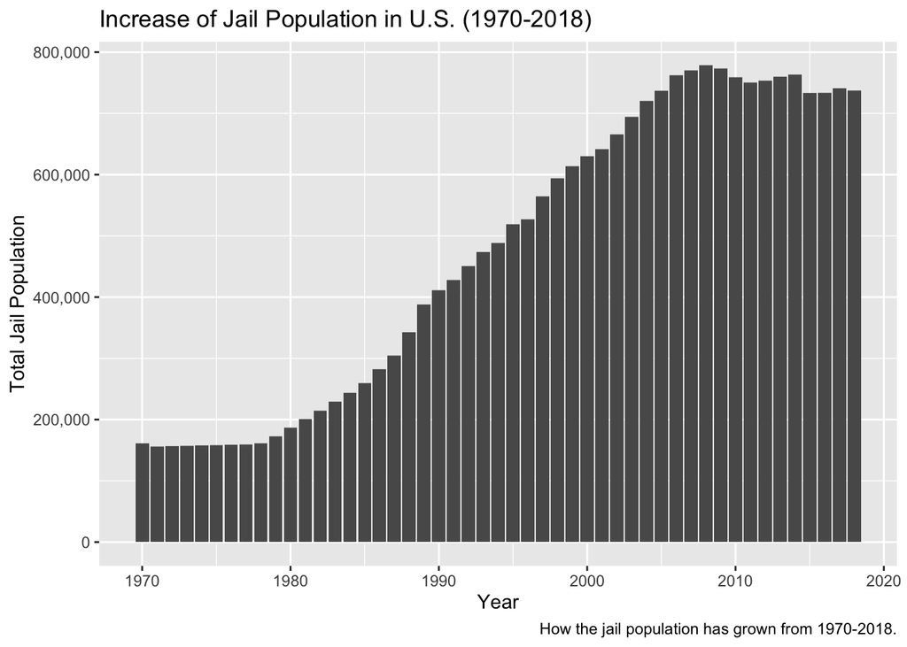

This chart shows that the jail population in the U.S. remains relatively steady from 1970-1980. The jail population then increases at a rate of about 20,000 people every year from 1980-2005. The jail population then starts to decrease over the course of 3 years, starting at about 2008 and then increases for 3 years. The population then jumps down in 2015 and remains steady again.

## Growth of Prison Population by State

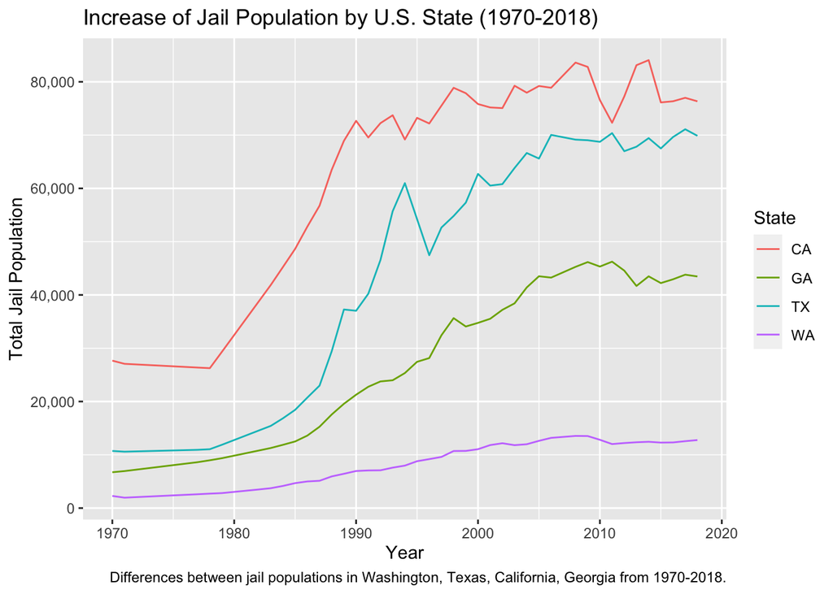

## Growth of Jailed Population by County Type

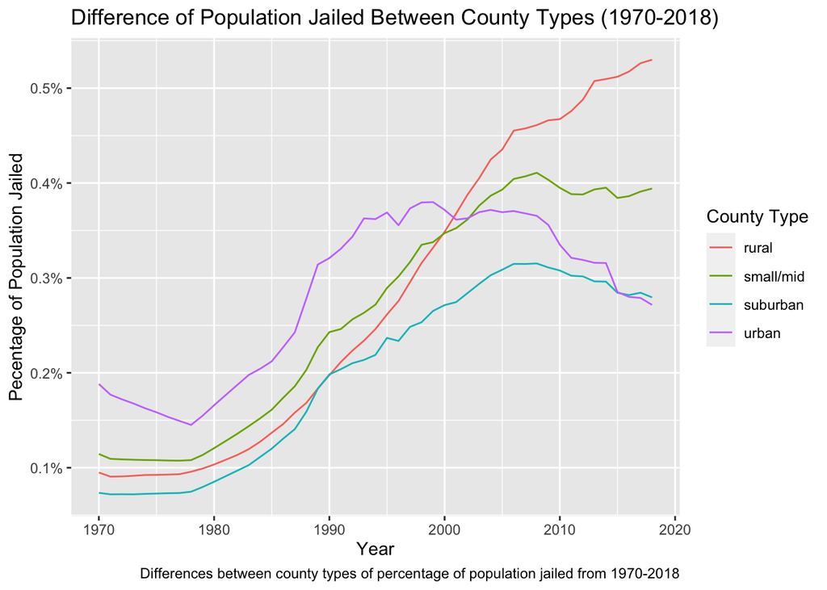

## Where Black People are Incarcerated More

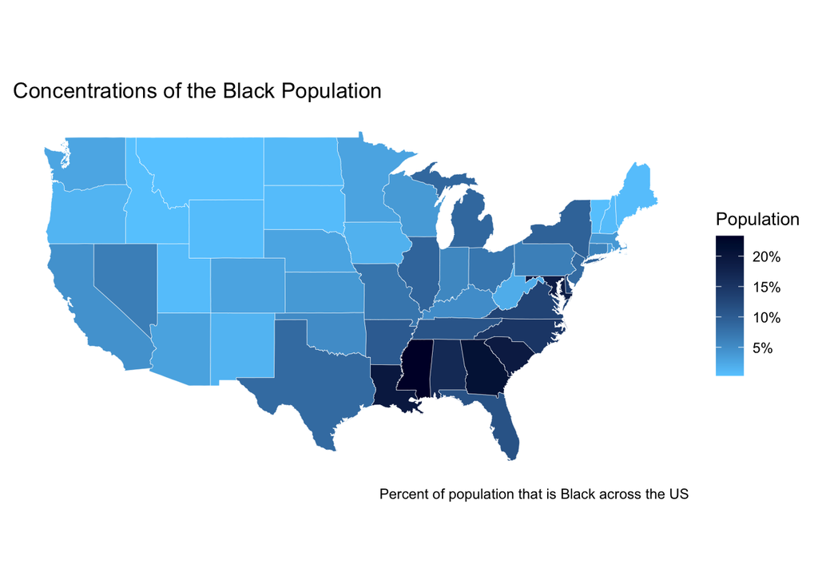

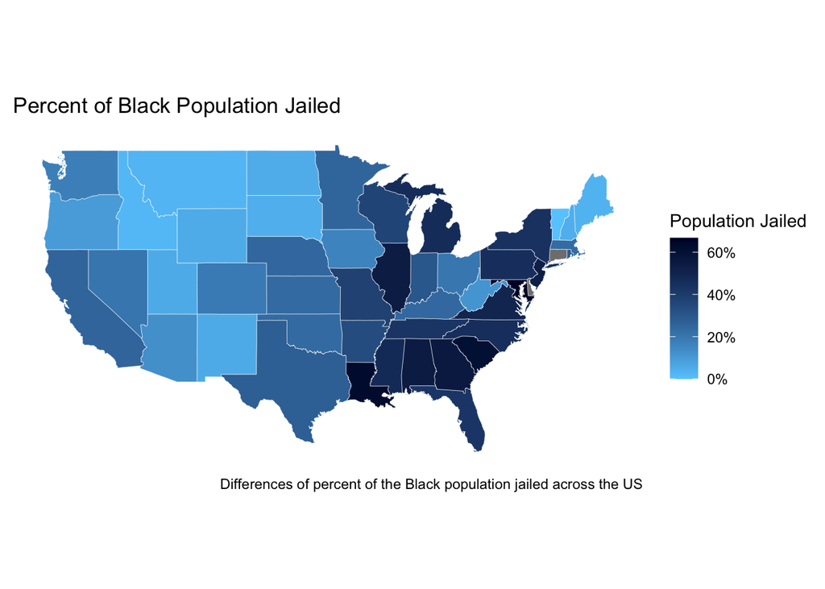